# 2018201743-张嘉辰-第八周作业

张嘉辰

2020年11月6日

# 3.2 分位数检验

## (1)画出分组箱线图

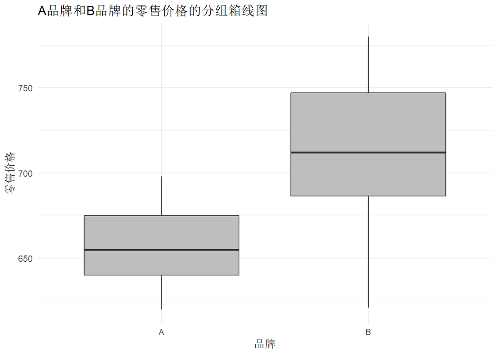

```r
#A品牌和B品牌的零售价格数据
A <- c(698, 688, 675, 656, 655, 648, 640, 639, 620)
B <- c(780, 754, 740, 712, 693, 680, 621)
AB <- c(A,B)

#A样本的样本量
l_A <- length(A)
#B样本的样本量
l_B <- length(B)
#混合样本的样本量
l_AB <- length(AB)

#构建包含样本的数据框
#第一列为因子类型，表示样本来自A品牌或B品牌
#第二列为样本值，表示A品牌和B品牌的零售价格数据
samp_df <- data.frame(
  brand = as.factor(c(rep("A", l_A), rep("B", l_B))),
  price = c(A, B)
)

library(ggplot2)
library(hrbrthemes)
#画出A品牌和B品牌的零售价格的分组箱线图
ggplot(samp_df, aes(x = brand, y = price)) +
  geom_boxplot(fill = "grey") +
  theme_minimal() +
  labs(x = "品牌", y = "零售价格",
       title = "A品牌和B品牌的零售价格的分组箱线图")
```

## (2)0.25分位数的检验

假设：

原假设和备择假设为

$H_0: Q_{X,0.25}=Q_{Y,0.25}$ vs $H_1: Q_{X,0.25}≠Q_{Y,0.25}$

检验过程：

```r
#混合样本的0.25分位数
Q1 <- quantile(AB, 0.25)

#混合样本中大于0.25分位数的样本点的个数
t_25 <- sum(AB>Q1)

#A样本中大于0.25分位数的样本点的个数
A_big_25 <- sum(A>Q1)


#A和B按照分布在Q.25两侧计数表
count_table_25 <- matrix(c(A_big_25, l_A-A_big_25, l_A, t_25-A_big_25, l_B-(t_25-A_big_25), l_B, t_25, l_AB-t_25, l_AB), 3, 3)
colnames(count_table_25) <- c("A", "B", "A+B")
rownames(count_table_25) <- c(">Q.25", "<Q.25", "TOTAL")
#显示列联表
knitr::kable(count_table_25, format = "html")
```

|  | A | B | A+B |
| --- | --- | --- | --- |
| >Q.25 | 6 | 6 | 12 |
| <Q.25 | 3 | 1 | 4 |
| TOTAL | 9 | 7 | 16 |

```r
#超几何分布计算0.25分位数检验的p值
p_25 <- 2*phyper(A_big_25, l_A, l_B, t_25)
p_25
```

```
## [1] 0.7846154
```

决策：

p>0.05，不能拒绝原假设，没有充足的证据认为A品牌和B品牌的0.25分位数有差异。

解释：

从列联表可以看到，A中大于混合样本0.25分位数的样本点个数与B中的相同（均为6）；

从分组箱线图可以看到，与中位数的差距和0.75分位数的差距相比，A和B的0.25分位数的差距相对小一些。

结合检验的p值，得出没有充足的证据认为A品牌和B品牌的0.25分位数有差异的结论。

## (3)0.75分位数的检验

假设：

原假设和备择假设为

$H_0: Q_{X,0.75}=Q_{Y,0.75}$ vs $H_1: Q_{X,0.75}≠Q_{Y,0.75}$

检验过程：

```r
#混合样本的0.25分位数
Q3 <- quantile(AB, 0.75)
#混合样本中大于0.25分位数的样本点的个数
t_75 <- sum(AB>Q3)

#A样本中大于0.25分位数的样本点的个数
A_big_75 <- sum(A>Q3)
#A样本的样本量
l_A_75 <- length(A)
#B样本的样本量
l_B_75 <- length(B)
#混合样本的样本量
l_AB_75 <- length(AB)

#A和B按照分布在Q.75两侧计数表
count_table_75 <- matrix(c(A_big_75, l_A-A_big_75, l_A, t_75-A_big_75, l_B-(t_75-A_big_75), l_B, t_75, l_AB-t_75, l_AB), 3, 3)
colnames(count_table_75) <- c("A", "B", "A+B")
rownames(count_table_75) <- c(">Q.75", "<Q.75", "TOTAL")
#显示列联表
knitr::kable(count_table_75, format = "html")
```

|  | A | B | A+B |
| --- | --- | --- | --- |
| >Q.75 | 0 | 4 | 4 |
| <Q.75 | 9 | 3 | 12 |
| TOTAL | 9 | 7 | 16 |

```r
#超几何分布计算0.75分位数检验的p值
p2 <- 2*phyper(A_big_75, l_A, l_B, t_75)
p2
```

```
## [1] 0.03846154
```

决策：

p<0.05，拒绝原假设，认为A品牌和B品牌的0.75分位数有差异。

解释：

从列联表可以看到，A中大于混合样本0.75分位数的样本点个数为0个，而B中为4个，A中大于混合样本0.75分位数的样本点个数明显小于B中的；

从分组箱线图可以看到，A和B的0.75分位数差距较大，A的0.75分位数小于B。

结合检验的p值，得出认为A品牌和B品牌的0.75分位数有差异的结论。

# 3.4 课时差别

## (1)讲课的课时的差别

假定A学院和B学院教师一年的课时量的的总体分布有类似形状，

即样本$X_1,X_2,...,X_m \sim F(x)$和$Y_1,Y_2,...,Y_m \sim F(x-\Delta)$

原假设与备择假设为

$H_0: \Delta = 0$ vs $H_1: \Delta ≠ 0$

$\Delta$表示两样本位置参数的差异，

在此题中即为两个学院教师讲课的课时的差别。

使用Wilcoxon秩和检验。

```r
A_teach <- c(221, 166, 156, 186, 130, 129, 103, 134, 199, 121, 265, 150, 158, 242, 243, 198, 138, 117)
B_teach  <- c(488, 593, 507, 428, 807, 342, 512, 350, 672, 589, 665, 549, 451, 492, 514, 391, 366, 469)

#进行wilcoxon检验
wilcox.test(B_teach , A_teach)
```

```
##
##  Wilcoxon rank sum test
##
## data:  B_teach and A_teach
## W = 324, p-value = 2.204e-10
## alternative hypothesis: true location shift is not equal to 0
```

```r
#p值为2.204e-10，拒绝原假设，即认为为两个学院教师讲课的课时不同。

#估计两个学院教师讲课的课时的差别，即Δ
est_diff_wil <- wilcox.test(B_teach, A_teach, conf.int = TRUE)$estimate
est_diff_wil
```

```
## difference in location
##                  331.5
```

p<0.05，拒绝原假设，即认为为两个学院教师讲课的课时不同。

使用Wilcoxon估计得到的两个学院教师讲课的课时的差别是331.5。

## (2)完成讲课任务的情况不类似

原假设和备择假设为

$H_0: Median_A=Median_B$ vs $H_1: Median_A≠Median_B$

使用Brown-Mood中位数检验。

采用超几何分布和用RVAideMemoire包中的mood.medtest()函数两种方法计算p值，得到的p值相同，结论一致。

### 方法一：根据超几何分布计算p值

```r
#混合样本
AB_teach <- c(A_teach, B_teach)
#混合样本的中位数
M_AB_teach  <- median(AB_teach)
#混合样本中大于中位数的样本点的个数
t_teach <- sum(AB_teach>M_AB_teach)

#A样本中大于中位数的样本点的个数
A_big_teach <- sum(A_teach>M_AB_teach)
#A样本的样本量
l_A_teach <- length(A_teach)
#B样本的样本量
l_B_teach <- length(B_teach)
#混合样本的样本量
l_AB_teach <- length(AB_teach)

#A和B按照分布在中位数两侧计数表
count_table_teach <- matrix(c(A_big_teach, l_A_teach-A_big_teach, l_A_teach, t_teach-A_big_teach, l_B-(t_teach-A_big_teach), l_B_teach, t_teach, l_AB_teach-t_teach, l_AB_teach), 3, 3)
colnames(count_table_teach) <- c("A", "B", "A+B")
rownames(count_table_teach) <- c(">M_AB", "<M_AB", "TOTAL")
#显示列联表
knitr::kable(count_table_teach, format = "html")
```

|  | A | B | A+B |
| --- | --- | --- | --- |
| >M_AB | 0 | 18 | 18 |
| <M_AB | 18 | -11 | 18 |
| TOTAL | 18 | 18 | 36 |

```r
#运用超几何分布计算Brown-Mood中位数检验的p值
#p值为2.203824e-10，拒绝原假设
p_BM_medi <- 2*phyper(A_big_teach, l_A_teach, l_B_teach, t_teach)
p_BM_medi
```

```
## [1] 2.203824e-10
```

### 方法二，使用RVAideMemoire包中的mood.medtest()函数进行检验

```r
AB_value <- AB_teach
#因子类型，表示A学院或B学院
AB_school <- as.factor(c(rep("A", l_A_teach),rep("B", l_B_teach)))
library(RVAideMemoire)
#使用RVAideMemoire包中的mood.medtest()函数进行检验
#p值为2.204e-10，拒绝原假设
mood.medtest(AB_value~AB_school)
```

```
##
##  Mood's median test
##
## data:  AB_value by AB_school
## p-value = 2.204e-10
```

两种方法计算得到的p值相等，p<0.05，拒绝原假设，认为两个学院教师完成讲课任务的情况不类似。

# 3.7.4 三种估计

## (1)点图

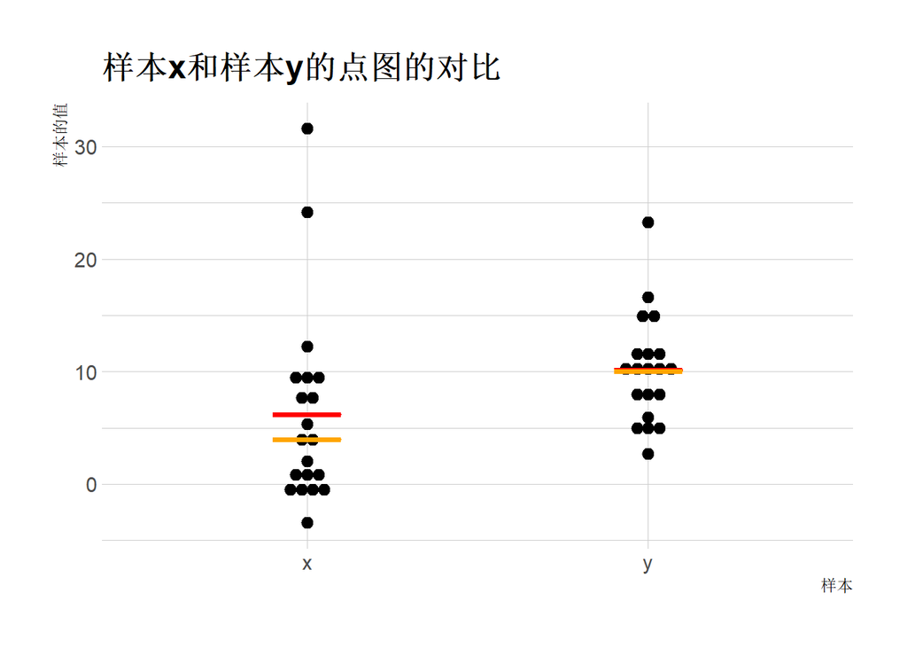

```r
set.seed(1)
#抽样
x <- log(rf(20,1,0.25))
y <- log(rf(20,1,0.25)) + 7


#构建数据框
#第一列为x和y的样本值，第二列为0或1，0表示来自样本x，1表示来自样本y
df <- data.frame(value = c(x, y), sample = c(rep(0, 20),rep(1, 20)))

#画出点图
#构建数据框用于画图
#第一列为x和y的样本值，第二列为因子类型，表示来自x样本或y样本
df_plot <- data.frame(sample = as.factor(c(rep("x", 20),rep("y", 20))), value = c(x, y))
library(ggplot2)
library(hrbrthemes)
library(Hmisc)
#画出点图
p <- ggplot(df_plot, aes(x = sample, y = value)) +
   geom_dotplot(binaxis='y', stackdir='center', binwidth = 1)+
   theme_ipsum()
p <- p +
#增加均值线，颜色为红色
  stat_summary(fun = "mean", geom = "crossbar",
             mapping = aes(ymin = ..y.., ymax = ..y..), width = 0.2, color="red") +
#增加中位数线，颜色为橙色
  stat_summary(fun = "median", geom = "crossbar",
             mapping = aes(ymin = ..y.., ymax = ..y..), width = 0.2, color="orange") +
  labs(x = "样本", y = "样本的值", title = "样本x和样本y的点图的对比")
p
```

## (2)Δ的估计

通过相应的函数求解估计值和估计的方差。

```r
library(npsm)
library(Rfit)
#LS（最小方差）估计
est_LS <- coef(summary(lm(value~sample, data = df)))[2,1]
est_LS
```

```
## [1] 3.961158
```

```r
#LS估计的标准误
est_LS_se <- coef(summary(lm(value~sample, data = df)))[2,2]
est_LS_se
```

```
## [1] 2.21619
```

```r
#wilcoxon估计
#用wilcox.test()函数估计
est_wil <- wilcox.test(y, x, conf.int = TRUE)$estimate
est_wil
```

```
## difference in location
##               5.450424
```

```r
#或者用rfit()函数估计
est_wil_rfit <- coef(summary(rfit(value~sample, data = df)))[2,1]
est_wil_rfit
```

```
## [1] 5.450236
```

```r
#wilcoxon估计的标准误
est_wil_se <- coef(summary(rfit(value~sample, data = df)))[2,2]
est_wil_se
```

```
## [1] 1.827428
```

```r
#bentscores1适用于右偏分布
library(npsm)
#用rank.test()函数估计
est_bent <- rank.test(x, y, scores = bentscores1, conf.int = TRUE)$estimate
est_bent
```

```
## Estimate
## 6.122502
```

```r
library(Rfit)
#或者用rfit()函数估计
est_bent_rfit <- coef(summary(rfit(value~sample, data = df, scores = bentscores1)))[2,1]
est_bent_rfit
```

```
## [1] 6.122502
```

```r
#bentscores1计分估计的标准误
est_bent_se <- coef(summary(rfit(value~sample, data = df, scores = bentscores1)))[2,2]
est_bent_se
```

```
## [1] 1.657181
```

```r
#输出结果
est <- data.frame("LS估计" = c(est_LS, est_LS_se),
  "wilcoxon估计" = c(est_wil_rfit, est_wil_se),
  "bentscores1计分估计" = c(est_bent_rfit, est_bent_se))
row.names(est) <- c("估计值", "标准误")
knitr::kable(est, format = "html")
```

|  | LS估计 | wilcoxon估计 | bentscores1计分估计 |
| --- | --- | --- | --- |
| 估计值 | 3.961158 | 5.450236 | 6.122502 |
| 标准误 | 2.216190 | 1.827428 | 1.657181 |

# 3.7.5 经验ARE

通过多次抽样，计算三种估计之间的经验ARE。

这里，两个估计之间的经验ARE是其均方误差之比，即

$$\operatorname{ARE}\left(\widehat{\Delta}_{1}, \widehat{\Delta}_{2}\right)=\frac{MSE_{2}}{MSE_{1}}=
\frac{bias_{2}^{2}+\sigma_{2}^{2}}{bias_{1}^{2}+\sigma_{1}^{2}}$$

如果这一比值小于1，则$\widehat{\Delta}_{2}$ 比 $\widehat{\Delta}_{1}$ 更有效。

```r
set.seed(1234)
x <- log(rf(20,1,0.25))
y <- log(rf(20,1,0.25)) + 7
library(npsm)
#抽样次数为nsims次
nsims <- 10000
#记录每次抽样得到的LS,wilcoxon,bentscore1的估计值
est_LS_sim <- rep(0,nsims)
est_wil_sim <- rep(0,nsims)
est_bent_sim <- rep(0,nsims)

for(i in 1:nsims){
  x <- log(rf(20,1,0.25))
  y <- log(rf(20,1,0.25)) + 7
#LS估计
  est_LS_sim[i] <- coef(summary(lm(value~sample, data = df)))[2,1]
#wilcoxon估计
  est_wil_sim[i] <- wilcox.test(y, x, conf.int = TRUE)$estimate
#bentscores1计分估计
  est_bent_sim[i] <- rank.test(x, y, scores = bentscores1, conf.int = TRUE)$estimate
}

#Δ的真实值
delta_true <- 7

#计算三种估计量的均方误差
#均方误差等于估计量偏差的平方加估计量的方差
MSE_LS_sim <- (mean(est_LS_sim)-delta_true)^2+var(est_LS_sim)
MSE_wil_sim <- (mean(est_wil_sim)-delta_true)^2+var(est_wil_sim)
MSE_bent_sim <- (mean(est_bent_sim)-delta_true)^2+var(est_bent_sim)
#LS估计的均方误差
MSE_LS_sim
```

```
## [1] 9.234561
```

```r
#wilcoxon估计的均方误差
MSE_wil_sim
```

```
## [1] 4.356168
```

```r
#bentscores1计分估计的均方误差
MSE_bent_sim
```

```
## [1] 3.079415
```

```r
#输出三种估计的均方误差的结果
MSE_sim <- data.frame("LS估计" = c(MSE_LS_sim),
  "wilcoxon估计" = c(MSE_wil_sim),
  "bentscores1计分估计" = c(MSE_bent_sim))
row.names(MSE_sim) <- c("均方误差")
knitr::kable(MSE_sim, format = "html")
```

|  | LS估计 | wilcoxon估计 | bentscores1计分估计 |
| --- | --- | --- | --- |
| 均方误差 | 9.234561 | 4.356168 | 3.079415 |

```r
#计算估计量之间的经验ARE
#根据定义，估计1与估计2的ARE小于1，表示估计2比估计1更有效
ARE_LS_wil <- MSE_wil_sim/MSE_LS_sim
#LS估计与wilcoxon估计的ARE小于1，表示wilcoxon估计比LS估计更有效
ARE_LS_wil
```

```
## [1] 0.4717245
```

```r
ARE_LS_bent <- MSE_bent_sim/MSE_LS_sim
#LS估计与bentscores1计分估计的ARE小于1，表示bentscores1计分估计比LS估计更有效
ARE_LS_bent
```

```
## [1] 0.3334663
```

```r
#wilcoxon估计与bentscores1计分估计的ARE小于1，表示bentscores1计分估计比wilcoxon估计更有效
ARE_wil_bent <- MSE_bent_sim/MSE_wil_sim
ARE_wil_bent
```

```
## [1] 0.7069092
```

```r
#输出三种估计之间的经验ARE
ARE_empi <- data.frame("LS与wilcoxon" = c(ARE_LS_wil),
  "LS与bentscores1" = c(ARE_LS_bent),
  "wilcoxon与bentscores1" = c(ARE_wil_bent))
row.names(ARE_empi) <- c("经验ARE")
knitr::kable(ARE_empi, format = "html")
```

|  | LS与wilcoxon | LS与bentscores1 | wilcoxon与bentscores1 |
| --- | --- | --- | --- |
| 经验ARE | 0.4717245 | 0.3334663 | 0.7069092 |

因此，由三种估计之间的经验ARE，三种估计中最有效的是bentscores1计分估计，次之是wilcoxon估计，有效性最低的是LS估计。